# Coursework Report: Green Study

*N* removed NAs: 4

*N* removed <18: 25

[output not shown]

[output not shown]

**Main analysis results**

# Coursework Report: Green Study

Analysing Data, Spring 2020

# Methods

## Participants

Participant Descriptives by Condition and Gender

| Condition | Gender | *N* | *M*<sub>Age</sub> | *SD*<sub>Age</sub> |
| --- | --- | --- | --- | --- |
| control | female | 31 | 20.7 | 3.59 |
| control | male | 22 | 20.4 | 1.68 |
| control | other | 15 | 20.6 | 1.88 |
| experimental | female | 33 | 20.6 | 1.62 |
| experimental | male | 20 | 20.1 | 1.73 |
| experimental | other | 18 | 20.9 | 1.86 |

## Design

The study was a full replication of that carried out by Griskevicius et al, with an initial hypothesis that wished to determine whether or not people made more environmentally friendly purchasing choices as a way to improve their status, even if the more environmentally friendly choice is less luxurious than a less green alternative (V. Griskevicius et al., 2010). The research design was between subjects, and involved participants reading a short story that would either trigger status motivations, or was a neutral story, followed by a questionnaire asking participants about a car, a household cleaner, or a dishwasher, specifically whether they would rather buy a luxurious version, or a less attractive environmentally friendly version. The independent variable was status, operationalised by whether the participants read the status motivating story (experimental condition) or the neutral story (control condition). The dependent variable was what purchasing choices they made as a result of their condition, operationalised by the questionnaire and whether the participants chose the environmentally friendly models of each product, or the more luxurious models. Both variables were factors, and so interpreted with a Chi-Squared test.

# Results

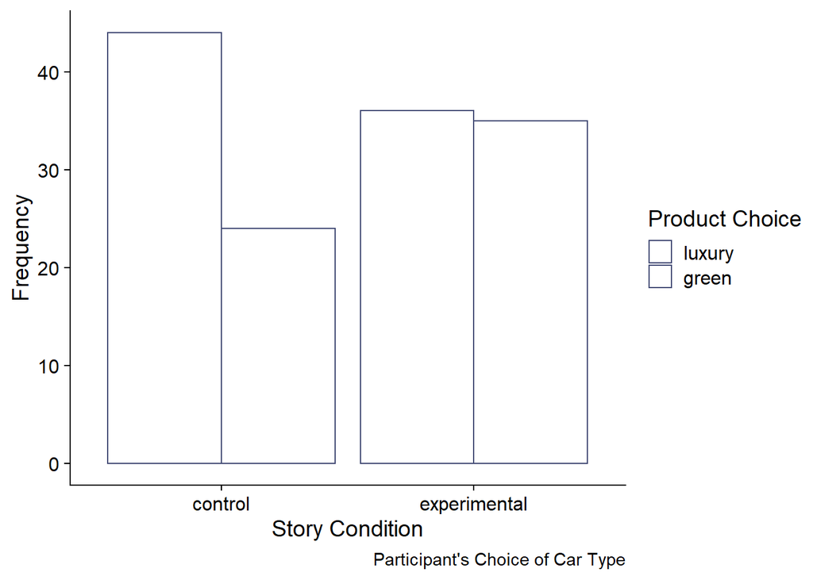

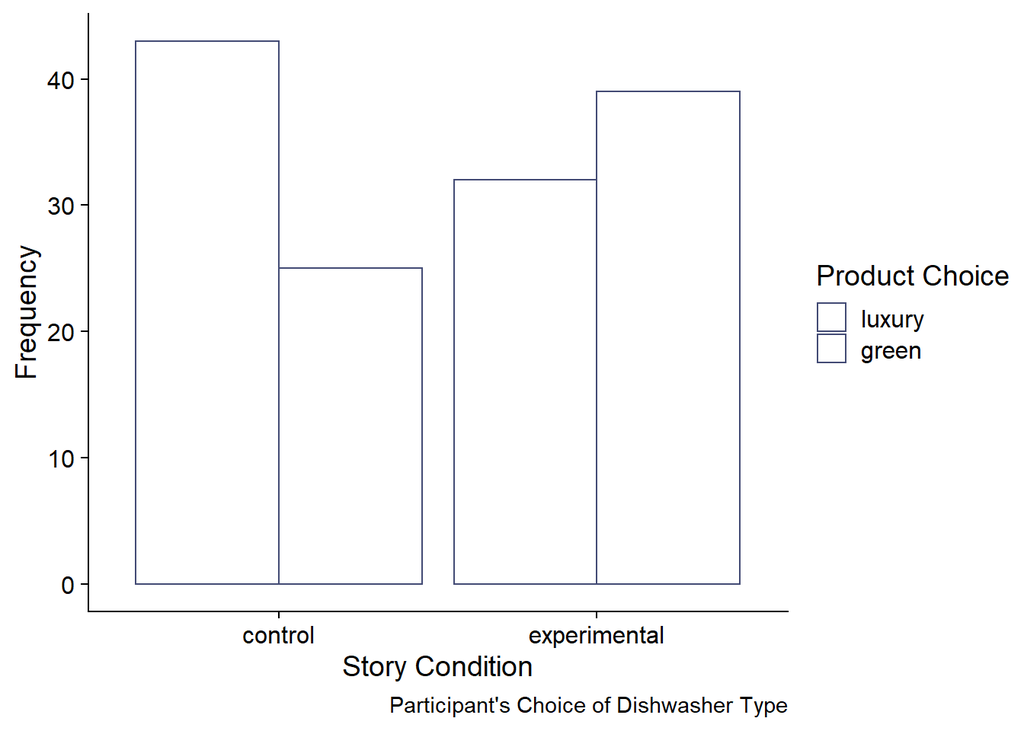

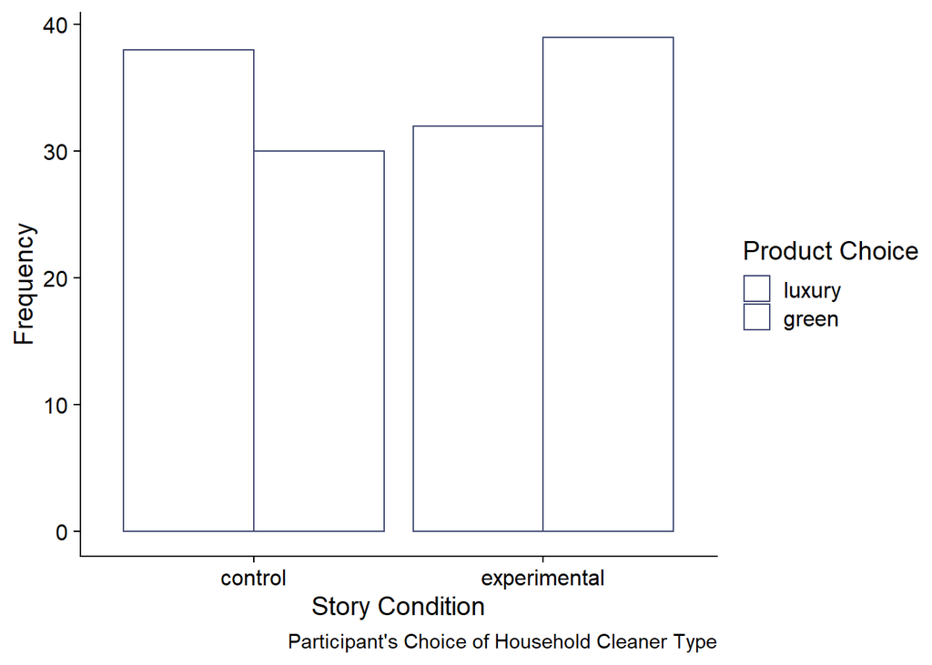

It can be seen that there are some differences in participants choices depending on whether or not they were status motivated or not. The general pattern, as can be seen in both the table and the bar graph, implies that participants were more likely to purchase green products if they had read the high status story (experimental condition) than if they had read the neutral story (control condition).

In order to further investigate this *X*<sup>2</sup> has been used, as all values are above the value of 5 and all variables are categorical. We are also looking for a p-value of less than 0.05, or 5%. For participant’s selection of cars, there was not a significant association found, *X*<sup>2</sup> (1) = 2.24, *p* = 0.13. For participant’s selection of dishwashers, there was a significant association found, *X*<sup>2</sup> (1) = 3.91, *p* = 0.05. Finally, participant’s choice of household cleaners returned no significant association, *X*<sup>2</sup> (1) = 1.22, *p* = 0.27. Overall therefore it can be seen that participant’s status and choice between green or non-green luxury products are not associated, however there may be some exceptions.

# Discussion

The research aimed to discover whether people were more likely to purchase environmentally friendly products that were less luxurious if they felt it would give them a higher status. The results in this study show that it is unlikely that status motives and purchasing decisions are associated in any way, because although the results for the *X*<sup>2</sup> test for participants purchase choices of dishwashers gave significant results, the other two tests provided insufficient evidence to support the theory. This differs a lot from the original study, which claimed that it was unlikely that status motives and purchasing green products were independent (V. Griskevicius et al., 2010). Due to the fact that our study was a direct replication, this difference is most likely to be a result of the participants themselves, because they are the only change between the original research and our research. In the original research there were different proportions of men to women, whereas in our research not only were there different proportions of men to women, but we also factored in people of other genders. There could be a gender disparity in purchasing decisions, including those that may be to do with environmentally friendly purchasing, as well as status motivations. As a result, the data collected would be very different between the two studies. Future improvements could be made here in a number of ways. For example, this could be done by replicating the study, but then doing more statistical analyses on not only the general purchasing patterns of participants, but also on men’s and women’s purchasing decisions. This would then establish whether the difference was a result of gender or not. Another explanation for the differing results may be because theories such as Griskevicius’s are focused too much on selfish motivations such as status. Other researchers have suggested that “warm glow” (the term used for the good feeling people get after doing a good deed) and “nature experiences” (when a brands imagery emphasises nature and the environment) are more likely to encourage people to purchase green energy resources (Hartmann & Apaolaza-Ibáñez, 2012). Furthermore, research suggests that Griskevicius’s findings “reflect self-presentation biases” (Thøgersen, 2011), and that people really make purchasing decisions based on unselfish drives such as “universalism” (Thøgersen, 2011). As a result, based on these criticisms from other researchers, future improvements could also include replicating the study but looking into unselfish motivations as well as status. For example, in one condition participants could read the high status story before taking part in the questionnaire, as in the original experiment, and in another condition participants could read a story that elicited feelings of universalism instead in order to establish whether this would have a more significant impact than status.

There is no doubt that status is very important within psychology, and that “the desire for status is a fundamental human motive” (Anderson et al., 2015). This is especially the case when it comes to spending, as how people spend their money has been shown to give certain messages to those around them. For example men who spend money on “showy purchases” are more likely to be seen by women near them as being driven by “short term mating motives” (Sundie et al., 2011). Status has also been shown to be important in terms of spending in other ways. There is further research that also supports Griskevicius’s theory that status can be used to encourage people to purchase items that are more environmentally friendly. Steg and colleagues proposed the integrated framework for encouraging pro-environmental behaviour (IFEP), which was made up of a number of different goal types, including hedonic, gain, and normative (Steg et al., 2014). They argued that it could be used to encourage people to buy more green products through either a. “actual or perceived outcomes of environmental behaviour can be changed” in order to increase the numbers of green purchases, or b. to “strengthen normative goals” so as to encourage people through social influences to purchase more green items (Steg et al., 2014). The overall conclusion from this study, therefore, is that status doesn’t necessarily motivate people to purchase green items, as the results of this study indicate status and shopping preferences to be independent of each other, and other research implies support for this. That being said, further replications of this study, or generally further research into this area, is clearly required. This is because other research, namely that of Griskevicius and his colleagues, is very much in support of the opposite, along with other researchers who believe the same.

# References

Anderson, C., Hildreth, J. A. D., & Howland, L. (2015). Is the desire for status a fundamental human motive? A review of the empirical literature. Psychological Bulletin, 141(3), 574–601. https://doi.org/10.1037/a0038781

Hartmann, P., & Apaolaza-Ibáñez, V. (2012). Consumer attitude and purchase intention toward green energy brands: The roles of psychological benefits and environmental concern. Journal of Business Research, 65(9), 1254–1263. https://doi.org/10.1016/j.jbusres.2011.11.001

Steg, L., Bolderdijk, J. W., Keizer, K., & Perlaviciute, G. (2014). An Integrated Framework for Encouraging Pro-environmental Behaviour: The role of values, situational factors and goals. Journal of Environmental Psychology, 38, 104–115. https://doi.org/10.1016/j.jenvp.2014.01.002

Sundie, J. M., Kenrick, D. T., Griskevicius, V., Tybur, J. M., Vohs, K. D., & Beal, D. J. (2011). Peacocks, Porsches, and Thorstein Veblen: Conspicuous consumption as a sexual signaling system. Journal of Personality and Social Psychology, 100(4), 664–680. https://doi.org/10.1037/a0021669

Thøgersen, J. (2011). Green Shopping: For Selfish Reasons or the Common Good? American Behavioral Scientist, 55(8), 1052–1076. https://doi.org/10.1177/0002764211407903

V. Griskevicius, J. M. Tybur, & B. Van Den Bergh. (2010, March). Going green to be seen: Status, reputation, and conspicuous conservation - ProQuest. https://search.proquest.com/docview/614510056?rfr_id=info%3Axri%2Fsid%3Aprimo